# Kiwi Analytics Assignment

Fang-Wen, Hsiao (Data Analyst)

June 10th, 2024

### Step 1: Load Data

```python
%pip install seaborn

import pandas as pd
import numpy as np
import matplotlib.pyplot as plt
import seaborn as sns
import statsmodels.api as sm
from sklearn.model_selection import train_test_split # splitting data into training and testing sets.
from sklearn.linear_model import LinearRegression, LogisticRegression
from sklearn.metrics import classification_report, confusion_matrix, accuracy_score # evaluating the model
from sklearn.metrics import mean_squared_error, r2_score
```

```python
driver_ids_df = pd.read_csv('/Users/HsiaoFangwen/Desktop/Phiture/driver_ids.csv')
ride_ids_df = pd.read_csv('/Users/HsiaoFangwen/Desktop/Phiture/ride_ids.csv')
ride_timestamps_df = pd.read_csv('/Users/HsiaoFangwen/Desktop/Phiture/ride_timestamps.csv')
```

### Step 2: Data Exploration

1. Dataset overview
2. Dataset information
3. Dataset duplicates
4. Dataset anomalies

```python
driver_ids_df
```

|  | driver_id | driver_onboard_date |
| --- | --- | --- |
| 0 | 002be0ffdc997bd5c50703158b7c2491 | 2016-03-29 00:00:00 |
| 1 | 007f0389f9c7b03ef97098422f902e62 | 2016-03-29 00:00:00 |
| 2 | 011e5c5dfc5c2c92501b8b24d47509bc | 2016-04-05 00:00:00 |
| 3 | 0152a2f305e71d26cc964f8d4411add9 | 2016-04-23 00:00:00 |
| 4 | 01674381af7edd264113d4e6ed55ecda | 2016-04-29 00:00:00 |
| ... | ... | ... |
| 932 | ff419a3476e21e269e340b5f1f05414e | 2016-04-26 00:00:00 |
| 933 | ff714a67ba8c6a108261cd81e3b77f3a | 2016-03-28 00:00:00 |
| 934 | fff482c704d36a1afe8b8978d5486283 | 2016-04-08 00:00:00 |
| 935 | fffecccc49436c5389075b13209f0dfa | 2016-05-06 00:00:00 |
| 936 | ffff51a71f2f185ec5e97d59dbcd7a78 | 2016-05-04 00:00:00 |

937 rows × 2 columns

```python
ride_ids_df

# Columns definition:
## ride_distance: Ride distance in *meters*
## ride_duration: Ride durations in *seconds*
```

|  | driver_id | ride_id | ride_distance | ride_duration | ride_prime_time |
| --- | --- | --- | --- | --- | --- |
| 0 | 002be0ffdc997bd5c50703158b7c2491 | 006d61cf7446e682f7bc50b0f8a5bea5 | 1811 | 327 | 50 |
| 1 | 002be0ffdc997bd5c50703158b7c2491 | 01b522c5c3a756fbdb12e95e87507eda | 3362 | 809 | 0 |
| 2 | 002be0ffdc997bd5c50703158b7c2491 | 029227c4c2971ce69ff2274dc798ef43 | 3282 | 572 | 0 |
| 3 | 002be0ffdc997bd5c50703158b7c2491 | 034e861343a63ac3c18a9ceb1ce0ac69 | 65283 | 3338 | 25 |
| 4 | 002be0ffdc997bd5c50703158b7c2491 | 034f2e614a2f9fc7f1c2f77647d1b981 | 4115 | 823 | 100 |
| ... | ... | ... | ... | ... | ... |
| 193497 | ffff51a71f2f185ec5e97d59dbcd7a78 | fc717192b3512767269ff5a54b97af05 | 10127 | 1336 | 0 |
| 193498 | ffff51a71f2f185ec5e97d59dbcd7a78 | fd6fa5f9265d2cf83936ead663f9e0e7 | 1908 | 445 | 0 |
| 193499 | ffff51a71f2f185ec5e97d59dbcd7a78 | fe0857c43025264d337dfe1d8463e503 | 4039 | 875 | 0 |
| 193500 | ffff51a71f2f185ec5e97d59dbcd7a78 | ff0db0ca4557bf5b05b4da6f660a1ac1 | 4760 | 777 | 0 |
| 193501 | ffff51a71f2f185ec5e97d59dbcd7a78 | ff7dc29693f8c79ff103d350a7b6c157 | 3751 | 889 | 100 |

193502 rows × 5 columns

```python
ride_timestamps_df
```

|  | ride_id | event | timestamp |
| --- | --- | --- | --- |
| 0 | 00003037a262d9ee40e61b5c0718f7f0 | requested_at | 2016-06-13 09:39:19 |
| 1 | 00003037a262d9ee40e61b5c0718f7f0 | accepted_at | 2016-06-13 09:39:51 |
| 2 | 00003037a262d9ee40e61b5c0718f7f0 | arrived_at | 2016-06-13 09:44:31 |
| 3 | 00003037a262d9ee40e61b5c0718f7f0 | picked_up_at | 2016-06-13 09:44:33 |
| 4 | 00003037a262d9ee40e61b5c0718f7f0 | dropped_off_at | 2016-06-13 10:03:05 |
| ... | ... | ... | ... |
| 970400 | ffffccd77f47a3de26dfed9a851464b4 | requested_at | 2016-05-18 08:44:13 |
| 970401 | ffffccd77f47a3de26dfed9a851464b4 | accepted_at | 2016-05-18 08:44:21 |
| 970402 | ffffccd77f47a3de26dfed9a851464b4 | arrived_at | 2016-05-18 08:44:36 |
| 970403 | ffffccd77f47a3de26dfed9a851464b4 | picked_up_at | 2016-05-18 08:44:42 |
| 970404 | ffffccd77f47a3de26dfed9a851464b4 | dropped_off_at | 2016-05-18 09:11:37 |

970405 rows × 3 columns

```python
# Show dataset information
driver_ids_df.info()
ride_ids_df.info()
ride_timestamps_df.info()

# Notes:
## 1. one Null value in the timestamp column
## 2. change data type for driver_onboard_date & timestamp to datetime
```

```
<class 'pandas.core.frame.DataFrame'>
RangeIndex: 937 entries, 0 to 936
Data columns (total 2 columns):
 #   Column               Non-Null Count  Dtype
---  ------               --------------  -----
 0   driver_id            937 non-null    object
 1   driver_onboard_date  937 non-null    object
dtypes: object(2)
memory usage: 14.8+ KB
<class 'pandas.core.frame.DataFrame'>
RangeIndex: 193502 entries, 0 to 193501
Data columns (total 5 columns):
 #   Column           Non-Null Count   Dtype
---  ------           --------------   -----
 0   driver_id        193502 non-null  object
 1   ride_id          193502 non-null  object
 2   ride_distance    193502 non-null  int64
 3   ride_duration    193502 non-null  int64
 4   ride_prime_time  193502 non-null  int64
dtypes: int64(3), object(2)
memory usage: 7.4+ MB
<class 'pandas.core.frame.DataFrame'>
RangeIndex: 970405 entries, 0 to 970404
Data columns (total 3 columns):
 #   Column     Non-Null Count   Dtype
---  ------     --------------   -----
 0   ride_id    970405 non-null  object
 1   event      970405 non-null  object
 2   timestamp  970404 non-null  object
dtypes: object(3)
memory usage: 22.2+ MB
```

```python
# Check driver_ids_dataset duplicates
driver_ids_duplicate = driver_ids_df[driver_ids_df.duplicated()]

print("Duplicate Rows :")
driver_ids_duplicate
```

```
Duplicate Rows :
```

|  | driver_id | driver_onboard_date |
| --- | --- | --- |

```python
# Check ride_ids_duplicate_dataset duplicates
ride_ids_duplicate =ride_ids_df[ride_ids_df.duplicated()]

print("Duplicate Rows :")
ride_ids_duplicate
```

```
Duplicate Rows :
```

|  | driver_id | ride_id | ride_distance | ride_duration | ride_prime_time |
| --- | --- | --- | --- | --- | --- |

```python
# Check ride_timestamps_dataset duplicates
ride_timestamps_duplicate =ride_timestamps_df[ride_timestamps_df.duplicated()]

print("Duplicate Rows :")
ride_timestamps_duplicate
```

```
Duplicate Rows :
```

|  | ride_id | event | timestamp |
| --- | --- | --- | --- |

```python
# Check anomalies
ride_ids_df.describe()

# Notes:
## negative and extremely long data in ride_distance & ride_duration
## 500 in ride_prime_time
```

|  | ride_distance | ride_duration | ride_prime_time |
| --- | --- | --- | --- |
| count | 193502.000000 | 193502.000000 | 193502.000000 |
| mean | 6955.218266 | 858.966099 | 17.305893 |
| std | 8929.444606 | 571.375818 | 30.825800 |
| min | -2.000000 | 2.000000 | 0.000000 |
| 25% | 2459.000000 | 491.000000 | 0.000000 |
| 50% | 4015.000000 | 727.000000 | 0.000000 |
| 75% | 7193.000000 | 1069.000000 | 25.000000 |
| max | 724679.000000 | 28204.000000 | 500.000000 |

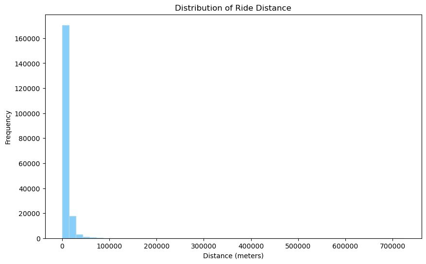

```python
# Use distribution analysis to see how the anomalies are distributed among the other data
# Distribution of ride_distance
plt.figure(figsize=(10, 6))
plt.hist(ride_ids_df['ride_distance'], bins=50, color='lightskyblue', edgecolor='lightblue')
plt.title('Distribution of Ride Distance')
plt.xlabel('Distance (meters)')
plt.ylabel('Frequency')
plt.grid(False)
plt.show()
```

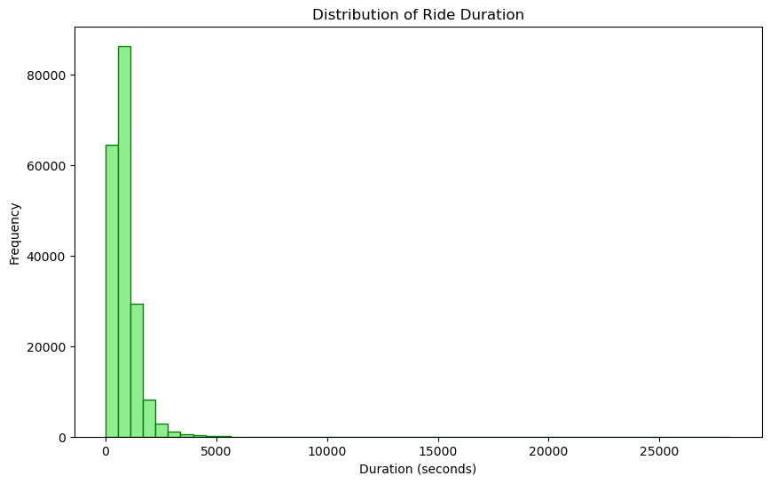

```python
# Distribution of ride_duration
plt.figure(figsize=(10, 6))
plt.hist(ride_ids_df['ride_duration'], bins=50, color='lightgreen', edgecolor='green')
plt.title('Distribution of Ride Duration')
plt.xlabel('Duration (seconds)')
plt.ylabel('Frequency')
plt.grid(False)
plt.show()
```

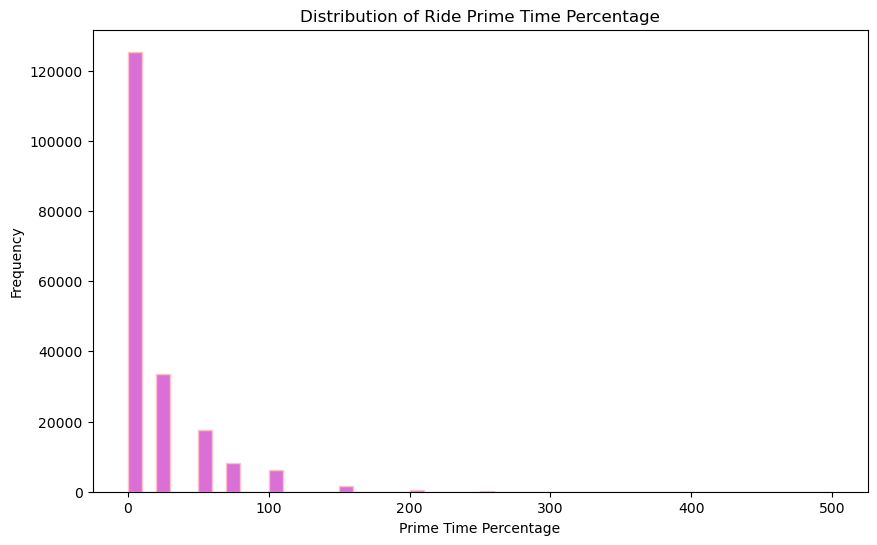

```python
# Distribution of ride_prime_time
plt.figure(figsize=(10, 6))
plt.hist(ride_ids_df['ride_prime_time'], bins=50, color='orchid', edgecolor='pink')
plt.title('Distribution of Ride Prime Time Percentage')
plt.xlabel('Prime Time Percentage')
plt.ylabel('Frequency')
plt.grid(False)
plt.show()
```

**Observations from Distribution Analysis**

Ride Distance:

Ride Duration:

- The majority of rides have durations under **2,000 seconds (approximately 33 minutes)** ≃96%.
- Similar to ride distances, there are some rides with very long durations.

Ride Prime Time Percentage:

- A large number of rides have a prime time percentage of 0%, indicating no prime time applied.
- There are peaks at common prime time percentages like 25%, 50%, and 100%.

```python
# Check the #of the anomalies for ride_distance to estimate the percentages
ride_ids_df[ride_ids_df['ride_distance'] > 100000].count()
```

```
driver_id          38
ride_id            38
ride_distance      38
ride_duration      38
ride_prime_time    38
dtype: int64
```

```python
# Check the #of the anomalies for ride_duration to estimate the percentages
ride_ids_df[ride_ids_df['ride_duration'] > 5000].count()
```

```
driver_id          165
ride_id            165
ride_distance      165
ride_duration      165
ride_prime_time    165
dtype: int64
```

#### 【Quick summary for Data Exploration】

**driver_ids_df**: Driver IDs and Onboard Dates

- Total 937 driver users
- Data Quality: No duplicates, no missing values

**ride_ids_df**: Ride Details

**ride_timestamps_df**: Ride Event Timestamps

- Total Events: 970,405
- Data Quality: 1 null value in the timestamp column, no duplicates

### Step 3: Data Wrangling

- Handle Anomalies / Null values
- Convert the data type (object -> datetime)
- Convert the units
  - Meters -> miles
  - Seconds -> mins

```python
ride_timestamps_df[ride_timestamps_df['timestamp'].isnull()]
```

|  | ride_id | event | timestamp |
| --- | --- | --- | --- |
| 434222 | 72f0fa0bd86800e9da5c4dced32c8735 | arrived_at | NaN |

```python
# Drop the missing values
ride_timestamps_df = ride_timestamps_df.dropna()
```

```python
# Handle the anomalies
# Use boolean indexing to filter out the anomalies rows
ride_ids_df = ride_ids_df[ride_ids_df['ride_distance'] <= 100000]
ride_ids_df = ride_ids_df[ride_ids_df['ride_distance'] != -2]
ride_ids_df = ride_ids_df[ride_ids_df['ride_duration'] < 5000]
ride_ids_df = ride_ids_df[ride_ids_df["ride_prime_time"] < 500]
```

```python
# Convert the driver_onboard_date from object to datetime
driver_ids_df['driver_onboard_date'] = pd.to_datetime(driver_ids_df['driver_onboard_date'])
```

```python
# Convert the timestamp from object to datetime
ride_timestamps_df['timestamp'] = pd.to_datetime(ride_timestamps_df['timestamp'])
```

```python
# Convert ride_distance from meters to miles and ride_duration from seconds to minutes
ride_ids_df['ride_distance_miles'] = ride_ids_df['ride_distance'] / 1609.34
ride_ids_df['ride_duration_minutes'] = ride_ids_df['ride_duration'] / 60
```

### Step 4: Data Analysis

1. *Q: Average Lifetime Value (LTV) of a Driver?*
- Why I want to know?
  - LTV -> driver acquisition and retention strategies.
- So what?
  - allocate resources efficiently, optimize marketing spend, and improve profitability by focusing on high-value drivers.
- Measured by:
  - LTV:
    - 1. Average Revenue Per User * Gross Margin / Churn Rate
      - *ps. Gross Margin assumption - unknown value*
    - 2. Avg.Revenue * Lifetime
      - *each driver's lifetime calculation*

*Findings:*

- Key Metrics
  - ARPU (Average Revenue Per User): **\$487**
  - Churn Rate: **15.9%**
  - Average Lifetime Value (LTV): **\$1531**
    - *PS. Actual numbers may vary since the gross margin is an example value.*
- Distribution Analysis
  - **Positive skewness**, indicating the majority has relatively lower LTV(high churn or low engagement) and a long tail towards higher values.
  - A noticeable number of drivers have LTV values between \$200 - \$800 a smaller segment has LTV values above \$1000 - \$2000.

*Recommendations*

- Enhance Retention
  - Reducing the (early)churn rate by **implementing improvements based on feedback, provide support or incentives.**
- Leverage Middle/High-Value Drivers:
  - **Offer a bonus/retention program** to increase engagement, analyze, and replicate the success of drivers with LTV above $1000.

```
ARPU: $ 487.0
Churn rate:  15.9 %
Average Lifetime Value (LTV): $ 1531.0
```

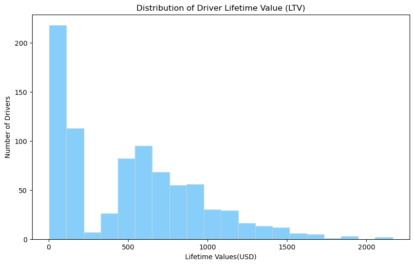

```python
# Rate card
base_fare = 2
cost_per_mile = 1.15
cost_per_min = 0.22
min_fare = 5
max_fare = 400
service_fee = 1.75
kiwi_revenue_percentage = 0.20
gross_margin = 0.5  # Example value, adjust based on actual data


# Fare calculation formula
## 1. $2.00 + Duration(min) * 0.22 + Distance(miles) * 1.15
## 2. Add prime-time if applicable
## 3. Enforce $5 minimum and $400 maximum
## 4. Add 1.75 Service Fee

# Add a new column to calculate the fare
# 1. Initial fare calculation
ride_ids_df['fare'] = base_fare + (ride_ids_df['ride_duration_minutes'] * cost_per_min) + (ride_ids_df['ride_distance_miles'] * cost_per_mile)
# 2. Prime time calculation: fare = fare + (fare * (ride_prime_time / 100)) -> fare += (fare * (ride_prime_time / 100))
ride_ids_df['fare'] += ride_ids_df['fare'] * (ride_ids_df['ride_prime_time'] / 100)
# 3. Check the minimum and maximum limit, then adds a service fee
# 3.1 Use lambda function to make sure the fare is within the limit
# 3.1-1 min(x, max_fare): Catch the fare at the maximum fare limit if x exceeds it.
# 3.1-1 max(min_fare, min(x, max_fare)): Catch the fare at the minimum fare limit if x belows it.
ride_ids_df['fare'] = ride_ids_df['fare'].apply(lambda x: max(min_fare, min(x, max_fare))) + service_fee


# Revenue calculation formula: value for Kiwi is 20% of the fare, excluding the service fee
# Add a new column to calculate the kiwi_revenue
ride_ids_df['kiwi_revenue'] = (ride_ids_df['fare'] - service_fee) * kiwi_revenue_percentage


# Calculate total revenue & totla_drivers & ARPU
total_revenue = ride_ids_df['kiwi_revenue'].sum()
total_drivers = driver_ids_df['driver_id'].nunique()
ARPU = total_revenue / total_drivers
print("ARPU: $", ARPU.round())


# Calculate churn rate : define churned drivers as those who haven't had any rides in the last 30 days
# Merge ride_timestamps & ride_id to get the driver_id
ride_driver_timestamps = ride_ids_df.merge(ride_timestamps_df, how='left', on='ride_id')
# Assume the latest date in timestamp as deadline and calculate prior 30 days as a baseline for a churn date
churn_date = ride_driver_timestamps['timestamp'].max() - pd.Timedelta(days=30)
# Calculate the last ride dates for each driver and compare it to churn date to see if the driver churned or not
last_ride_dates = ride_driver_timestamps.groupby('driver_id')['timestamp'].max().reset_index()
last_ride_dates.rename(columns={'timestamp': 'last_ride_date'}, inplace=True) #rename the column to be more specific
# Define churned drivers and count # of churned frivers
churned_drivers = last_ride_dates[last_ride_dates['last_ride_date'] < churn_date]
churned_drivers_count = churned_drivers['driver_id'].nunique()
# Churn rate = total of lost users / total users
churn_rate = churned_drivers_count / total_drivers
print("Churn rate: ", round(churn_rate * 100,2),'%')

LTV = (ARPU * gross_margin) / churn_rate
print("Average Lifetime Value (LTV): $", LTV.round())



# Visualize the driver lifetimes values distribution -> create a dataframe
# Lifetime calculation -> Merge last_ride_dates with driver_ids table to get onboarddate from each driver
driver_lifetime = driver_ids_df.merge(last_ride_dates, how='left', on='driver_id')

# Calculate the lifetime of each driver in days
driver_lifetime['lifetime_days'] = (driver_lifetime['last_ride_date'] - driver_lifetime['driver_onboard_date']).dt.days


# Calculate ARPU for each driver
total_revenue_per_driver = ride_ids_df.groupby('driver_id')['kiwi_revenue'].sum().reset_index()
# Merge total_revenue_per_driver & driver_lifetime into one table
driver_ltv_df = driver_lifetime.merge(total_revenue_per_driver, how='left' , on='driver_id')
# Add a new column called ARPU in driver_ltv_df
driver_ltv_df['ARPU'] = driver_ltv_df['kiwi_revenue'] / driver_ltv_df['lifetime_days']


# Calculate LTV for each driver -> LTV = (avg.revenue) * lifetime
driver_ltv_df['LTV'] = driver_ltv_df['ARPU'] * driver_ltv_df['lifetime_days']


plt.figure(figsize=(10, 6))
plt.hist(driver_ltv_df['LTV'], bins=20, color='lightskyblue', edgecolor='lightblue')
plt.title('Distribution of Driver Lifetime Value (LTV)')
plt.xlabel('Lifetime Values(USD)')
plt.ylabel('Number of Drivers')
plt.grid(False)
plt.show()
```

*1-1. Q:Any main factors affect a driver’s lifetime value?*

- Why I want to know?
  - Understanding what drives higher LTV
- So what?
  - tailor strategies to increase driver satisfaction and longevity, leading to higher profits.

*Recommendations:*

- Optimize Ride Assignments:
  - Focus on optimizing ride assignments and balance the number of rides and provide adequate breaks to maintain driver satisfaction and performance.
- Increase Earnings Opportunities:
  - Create incentive programs that reward drivers for reaching certain milestones, such as a high number of completed rides or positive customer feedback.
  - Peak Time Bonuses: Offer additional earnings opportunities during peak hours or high-demand periods.
- Reduce Wait Times:
  - Continue efforts to minimize wait times through efficient dispatch systems and better matching of drivers to passengers. Reducing idle time can improve the overall driver experience and contribute to retention.

```python
# This analysis focuses on internal influential factors
## such as less waiting time for drivers' arrival, ride frequency(#of completed rides), total earnings from drivers...etc.

# Calculate less waiting time for drivers & customers
# Pivot data to get the required wait times
wait_times = ride_timestamps_df.pivot_table(index='ride_id', columns='event', values='timestamp', aggfunc='first')
wait_times['wait_before_accepted'] = ((wait_times['accepted_at'] - wait_times['requested_at']).dt.total_seconds()/60).dropna()
wait_times['wait_before_arrived'] = ((wait_times['arrived_at'] - wait_times['accepted_at']).dt.total_seconds()/60).dropna()
wait_times['wait_before_pickup'] = ((wait_times['picked_up_at'] - wait_times['accepted_at']).dt.total_seconds()/60).dropna()

# Merge the wait times back to ride_ids_df
ride_ids_df = ride_ids_df.merge(wait_times[['wait_before_accepted','wait_before_arrived', 'wait_before_pickup']], on='ride_id', how='left')
```

```python
# Add total earnings
ride_ids_df['driver_earnings'] = ride_ids_df['fare'] - ride_ids_df['kiwi_revenue']


# Multiple aggregations
ride_factors = ride_ids_df.groupby('driver_id').agg(
    ride_count=('ride_id', 'count'),
    total_earnings=('driver_earnings', 'sum'),
    avg_wait_before_arrived=('wait_before_arrived', 'mean'),
    avg_wait_before_accepted=('wait_before_accepted', 'mean'),
    avg_wait_before_pickup=('wait_before_pickup', 'mean')
).reset_index()


# Linear Regression Analysis - the relationship between input & output variables
# Reference: https://www.statology.org/sklearn-linear-regression-summary/
# Show regression model summary instead of visualizing it

# Create an df to include all the needed infos
# Merged driver_ltv_df & ride_factors
ltv_factors = driver_ltv_df.merge(ride_factors, how='left', on='driver_id')
ltv_factors = ltv_factors.dropna()


# Define predictor/response variables
predictor_variables = ['ride_count','total_earnings','avg_wait_before_arrived','avg_wait_before_accepted', 'avg_wait_before_pickup']
response_variables = 'LTV'

x = ltv_factors[predictor_variables]
y = ltv_factors[response_variables]


# Add constant to predictor variables
x = sm.add_constant(x)

# Fit linear regression model
model = sm.OLS(y, x).fit()

# View model summary
print(model.summary())

# Extract coefficients for interpretation
coefficients = model.params
print(coefficients)
```

```
                            OLS Regression Results
==============================================================================
Dep. Variable:                    LTV   R-squared:                       1.000
Model:                            OLS   Adj. R-squared:                  1.000
Method:                 Least Squares   F-statistic:                 1.367e+32
Date:                Sat, 22 Jun 2024   Prob (F-statistic):               0.00
Time:                        21:05:12   Log-Likelihood:                 22582.
No. Observations:                 837   AIC:                        -4.515e+04
Df Residuals:                     831   BIC:                        -4.512e+04
Df Model:                           5
Covariance Type:            nonrobust
============================================================================================
                               coef    std err          t      P>|t|      [0.025      0.975]
--------------------------------------------------------------------------------------------
const                     -6.39e-13   7.63e-14     -8.381      0.000   -7.89e-13   -4.89e-13
ride_count                  -0.4375   6.49e-16  -6.74e+14      0.000      -0.438      -0.438
total_earnings               0.2500   5.73e-17   4.36e+15      0.000       0.250       0.250
avg_wait_before_arrived   -9.53e-15   1.34e-13     -0.071      0.943   -2.73e-13    2.54e-13
avg_wait_before_accepted -3.948e-14   2.55e-13     -0.155      0.877   -5.41e-13    4.62e-13
avg_wait_before_pickup    1.299e-13   1.38e-13      0.941      0.347   -1.41e-13    4.01e-13
==============================================================================
Omnibus:                       99.666   Durbin-Watson:                   1.171
Prob(Omnibus):                  0.000   Jarque-Bera (JB):              146.665
Skew:                          -0.842   Prob(JB):                     1.42e-32
Kurtosis:                       4.171   Cond. No.                     5.08e+04
==============================================================================

Notes:
[1] Standard Errors assume that the covariance matrix of the errors is correctly specified.
[2] The condition number is large, 5.08e+04. This might indicate that there are
strong multicollinearity or other numerical problems.
const                      -6.390438e-13
ride_count                 -4.375000e-01
total_earnings              2.500000e-01
avg_wait_before_arrived    -9.529964e-15
avg_wait_before_accepted   -3.947583e-14
avg_wait_before_pickup      1.299274e-13
dtype: float64
```

2. *Q: Average Projected Lifetime of a Driver?*
- Why I want to know?
  - Understanding this metric in forecasting driver availability and planning for recruitment and retention efforts.
- So what?
  - maintaining a steady supply of active drivers, which is crucial for meeting customer demand.

*Recommendations:*

- Retention Strategies:
  - Reduce the early drop-off rate. Strategies suggestions: **onboarding support or early engagement incentives**.
- Mid-term Support:
  - Enhance support to ensure they stay motivated. Strategies suggestions: **ongoing training, recognition programs, or periodic check-ins**.
- Long-term Incentives:
  - Strategies suggestions: **Conduct further analysis to understand the reasons or long-term engagement bonuses.**

```
Average Projected Lifetime:  55.0 days
```

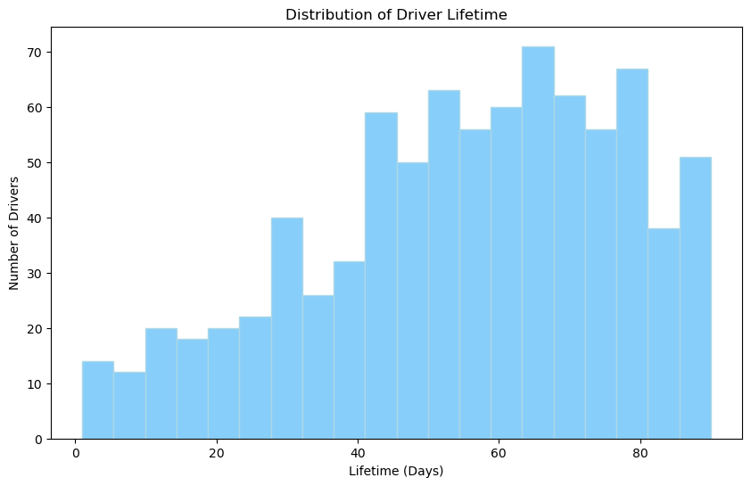

```python
# Calculate the average driver's lifetime
avg_lifetime = driver_lifetime['lifetime_days'].mean()
print("Average Projected Lifetime: ", avg_lifetime.round(), "days")
median_lifetime = driver_lifetime['lifetime_days'].median() #57
plt.figure(figsize=(10, 6))
plt.hist(driver_lifetime['lifetime_days'], bins=20, color='lightskyblue', edgecolor='lightblue')
plt. grid(False)
plt.title('Distribution of Driver Lifetime')
plt.xlabel('Lifetime (Days)')
plt.ylabel('Number of Drivers')
plt.grid(False)
plt.show()
```

3. *Q: What is driver churn rate?*
- Why I want to know?
  - For proactive measures to retain drivers and reduce turnover.
- So what?
  - lower recruitment costs and a more stable workforce to increase service reliability and customer satisfaction.

*Findings*

- Churn Rate: Approximately **15.9%**
- Active Drivers: 84.1%

*Recommendations*

- retention campaigns, driver support programm, conduct a survery to understand drivers

```
Churn rate:  15.9 %
```

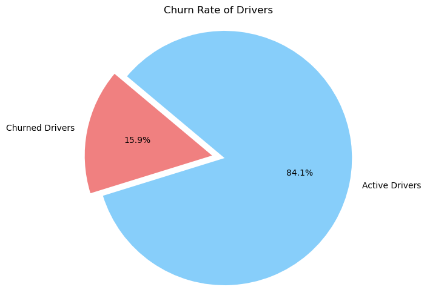

```python
# Calculate churn rate : define churned drivers as those who haven't had any rides in the last 30 days
# Churn rate = total of lost users / total users
total_drivers = driver_ids_df['driver_id'].nunique()
churn_rate = churned_drivers_count / total_drivers
print("Churn rate: ", round(churn_rate * 100,2),'%')

# Visualize the churn rate with pie chart
active_drivers_count = total_drivers - churned_drivers_count
labels = ['Churned Drivers', 'Active Drivers']
sizes = [churned_drivers_count, active_drivers_count]
colors = ['lightcoral', 'lightskyblue']
explode = (0.1, 0)  # explode the 1st slice for churned drivers
plt.figure(figsize=(6, 6))
plt.pie(sizes, explode=explode, labels=labels, colors=colors, autopct='%1.1f%%', startangle=140)
plt.title('Churn Rate of Drivers')
plt.axis('equal')  # to make sure pie is as a circle
plt.show()
```

3-1. *Q:Any predictive indicators for driver churn?*

- Why I want to know?
  - Address factors causing drivers to leave the platform and develop retention strategies.
- So what?
  - Prescribe the right medicine to reduce the churn rate

*Key Metrics from Logistic Regression*

- Model Performance:
  - Confusion Matrix:
    - Correctly classified 135 non-churned and 10 churned drivers. Misclassified 6 non-churned as churned and 17 churned as non-churned.
- Classification Report:
  - Precision: 0.89 for non-churned, 0.62 for churned.
  - Recall: 0.96 for non-churned, 0.37 for churned.
    - Overall accuracy: 86.31%.

*Findings*

- Total Earnings: Small positive coefficient suggests total earnings have a minimal impact on churn.
- Average Wait Before Accepted: Slight positive impact but not significant.
- Average Wait Before Arrived: **Strong positive impact**, indicating that longer waits before arrival increase churn risk.

*Recommendations*

- Reduce Wait Times:
  - optimize and real-time traffic updates and continue efforts to minimize wait times through efficient dispatch systems and better matching of drivers to passengers.

- Enhance Data Quality and Quantity:
  - Explore additional factors that might better predict churn, such as **driver demographics, behavior, or external factors**.

```
Confusion Matrix:
[[135   6]
 [ 17  10]]

Classification Report:
              precision    recall  f1-score   support

           0       0.89      0.96      0.92       141
           1       0.62      0.37      0.47        27

    accuracy                           0.86       168
   macro avg       0.76      0.66      0.69       168
weighted avg       0.85      0.86      0.85       168


Accuracy Score:
0.8630952380952381
```

[figure not shown]

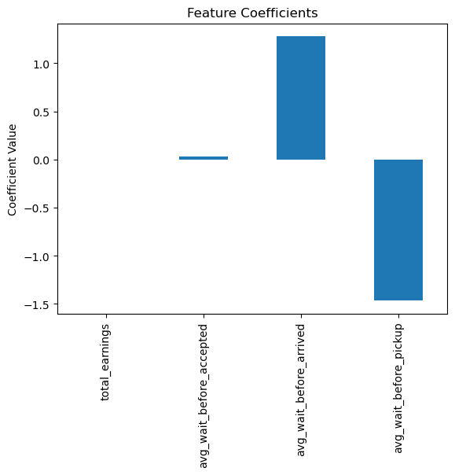

```python
# Use logistic regression to predict the internal factors:
# total_earnings, avg_wait_before_accepted,avg_wait_before_arrived', avg_wait_before_pickup
# Reference: https://www.datacamp.com/tutorial/understanding-logistic-regression-python
# Use 0/1 to denfine active/churned drivers
active_drivers = last_ride_dates[last_ride_dates['last_ride_date'] >= churn_date]
churned_drivers.loc[:, 'churned'] = 1
active_drivers.loc[:, 'churned'] = 0

churn_factors = ride_ids_df.groupby('driver_id').agg(
    total_earnings=('driver_earnings', 'sum'),
    avg_wait_before_accepted=('wait_before_accepted', 'mean'),
    avg_wait_before_arrived= ('wait_before_arrived', 'mean'),
    avg_wait_before_pickup=('wait_before_pickup', 'mean')
).reset_index()

# Create an df to include all the needed infos
# Concatenate churned_drivers & activer_drivers as 1 df
churn_data = pd.concat([churned_drivers, active_drivers])
# Merge with driver_ids_df to get onboard dates
churn_data = churn_data.merge(driver_ids_df, how='left', on='driver_id')
# Merge ride_factors with churn_data
churn_data = churn_data.merge(churn_factors, how='left', on='driver_id')
# Churn_data now includes
## driver_id, onboarding & last drive dates, ride count
## total earnings from drivers, avg ride duration, avg ride distance, churned or not (0/1)

# Fill missing values with 0 (in case some drivers have no rides)
churn_data = churn_data.dropna()

# Define features and target variable
features = ['total_earnings','avg_wait_before_accepted','avg_wait_before_arrived', 'avg_wait_before_pickup']
target = 'churned'

X = churn_data[features] # Features
y = churn_data[target] # Target variable

# Split the data into training and testing sets
X_train, X_test, y_train, y_test = train_test_split(X, y, test_size=0.2, random_state=60) #80% for training and 20% for testing

# Create a Logistic Regression model with a maximum of 1000 iterations
log_reg = LogisticRegression(max_iter=1000)

# Fit the model to the training data
log_reg.fit(X_train, y_train)

# Make predictions
y_pred = log_reg.predict(X_test)

# Evaluate the model
conf_matrix = confusion_matrix(y_test, y_pred)
print("Confusion Matrix:")
print(conf_matrix)
print("\nClassification Report:")
print(classification_report(y_test, y_pred))
print("\nAccuracy Score:")
print(accuracy_score(y_test, y_pred))

# Visualize the confusion matrix
plt.figure(figsize=(8, 6))
sns.heatmap(conf_matrix, annot=True, fmt='d', cmap='Blues', cbar=False,
            xticklabels=['Not Churned', 'Churned'], yticklabels=['Not Churned', 'Churned'])
plt.xlabel('Predicted')
plt.ylabel('Actual')
plt.title('Confusion Matrix')
plt.show()

# Visualize coefficients
coefficients = pd.DataFrame(log_reg.coef_.T, index=features, columns=['Coefficient'])
coefficients.plot(kind='bar', legend=False)
plt.title('Feature Coefficients')
plt.ylabel('Coefficient Value')
plt.show()
```

*4. Q:Do All Drivers Act Alike? Specific Segments of Drivers Generating More Value?*

- Why I want to know?
  - Understanding driver behavior variations helps tailor management and support strategies to different driver segments.
- So what?
  - Focusing on high-value drivers maximizes revenue and improves overall business performance by prioritizing the most profitable segments
- Measured by:
  - Analyzing revenue per driver and segmenting based on performance metrics (e.g., high-value, high-frequency drivers)

*Findings:*

- Segment Size and Revenue Distribution:
  - High-LTV, High-Frequency: This segment has the *highest number* of drivers (17%) and the highest average revenue (**\$1157**).
  - Low-LTV, Low-Frequency: This segment has the *second-highest number* of drivers (15%) but the second-lowest average revenue (**\$75.95**).
  - Mid-High-LTV, Mid-High-Frequency: This segment has 117 drivers (13%) with a significant average revenue (**\$655.93**).
  - Mid-Low-LTV, Mid-Low-Frequency: This segment has 97 drivers (11%) with moderate average revenue (**\$322.97**).

*Recommendations:*

- Targeted Loyalty Programs:
  - Develop exclusive loyalty programs for "High-LTV, High-Frequency" drivers to encourage continued high engagement and spending.
  - Offer personalized rewards and incentives to maintain their loyalty and maximize their lifetime value.
- Upsell and Cross-Sell Opportunities:
  - Identify and implement upsell and cross-sell opportunities for mid-frequency and mid-LTV segments.
  - Use targeted marketing campaigns to promote complementary services or products that align with their preferences and usage patterns.
- Customer Retention Strategies:
  - Design customer retention strategies for low-frequency and low-LTV segments. This could include tailored promotions, discounts, and engagement initiatives aimed at increasing their usage frequency and overall value.
  - Focus on understanding their needs and addressing any barriers to higher engagement.

```
segment
High-LTV, High-Frequency            149
Low-LTV, Low-Frequency              133
Mid-High-LTV, Mid-High-Frequency    117
Mid-Low-LTV, Mid-Low-Frequency       97
Mid-Low-LTV, Low-Frequency           77
High-LTV, Mid-High-Frequency         57
Mid-High-LTV, Mid-Low-Frequency      55
Low-LTV, Mid-Low-Frequency           54
Mid-High-LTV, High-Frequency         37
Mid-Low-LTV, Mid-High-Frequency      27
Low-LTV, High-Frequency              15
Mid-Low-LTV, High-Frequency           8
Low-LTV, Mid-High-Frequency           8
High-LTV, Mid-Low-Frequency           3
Name: count, dtype: int64
segment
High-LTV, High-Frequency            1157.325980
High-LTV, Mid-High-Frequency         950.289217
High-LTV, Mid-Low-Frequency          841.170888
Mid-High-LTV, High-Frequency         663.181258
Mid-High-LTV, Mid-High-Frequency     655.928934
Mid-High-LTV, Mid-Low-Frequency      585.598791
Mid-Low-LTV, Mid-High-Frequency      388.266518
Mid-Low-LTV, Mid-Low-Frequency       322.967431
Mid-Low-LTV, High-Frequency          318.221286
Mid-Low-LTV, Low-Frequency           143.280601
Low-LTV, Mid-Low-Frequency            82.018539
Low-LTV, Mid-High-Frequency           76.896405
Low-LTV, Low-Frequency                75.949127
Low-LTV, High-Frequency               70.842431
Name: LTV, dtype: float64
```

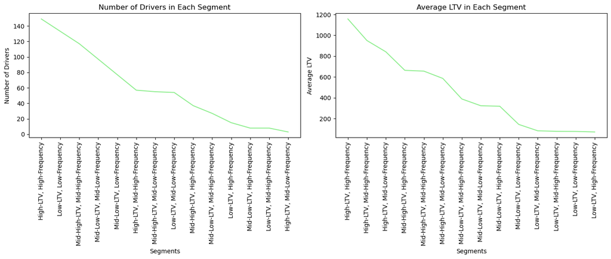

```python
import warnings

# Suppress specific FutureWarning messages
warnings.filterwarnings("ignore", category=FutureWarning, module='seaborn._oldcore')

ride_counts_df = ride_ids_df.groupby('driver_id').agg(total_rides = ('ride_id', 'count'))
driver_segments = ride_counts_df.merge(driver_ltv_df[['driver_id','LTV', 'lifetime_days']], on='driver_id')
driver_segments['ride_frequency'] = driver_segments['total_rides'] / driver_segments['lifetime_days']


# Define segments using pd.qcut
driver_segments['value_segment'] = pd.qcut(driver_segments['LTV'], q=4, labels=['Low-LTV', 'Mid-Low-LTV', 'Mid-High-LTV', 'High-LTV'])
driver_segments['frequency_segment'] = pd.qcut(driver_segments['ride_frequency'], q=4, labels=['Low-Frequency', 'Mid-Low-Frequency', 'Mid-High-Frequency', 'High-Frequency'])
# Concat value_segment + frequency_segment
driver_segments['segment'] = driver_segments['value_segment'].astype(str) + ', ' + driver_segments['frequency_segment'].astype(str)

driver_segments = driver_segments.dropna()

# Analyze the number of drivers in each segment
segment_counts = driver_segments['segment'].value_counts()
print(segment_counts)

# Calculate average revenue for each segment
segment_ltv = driver_segments.groupby('segment')['LTV'].mean().sort_values(ascending=False)
print(segment_ltv)

# Plot the number of drivers in each segment
plt.figure(figsize=(14, 6))
plt.subplot(1, 2, 1)
sns.lineplot(x=segment_counts.index, y=segment_counts.values, color='lightgreen')
plt.title('Number of Drivers in Each Segment')
plt.xlabel('Segments')
plt.ylabel('Number of Drivers')
plt.xticks(rotation=90)

# Plot the average revenue for each segment
plt.subplot(1, 2, 2)
sns.lineplot(x=segment_ltv.index, y=segment_ltv.values, color='lightgreen')
plt.title('Average LTV in Each Segment')
plt.xlabel('Segments')
plt.ylabel('Average LTV')
plt.xticks(rotation=90)

plt.tight_layout()
plt.show()
```